# R exercises

This notebook takes you through working with expenses data. First, [download the latest MPs’ expenses from IPSA](http://www.theipsa.org.uk/mp-costs/other-published-data/) - *make sure you select Individual Claims* to get the granular data.

## Import data

Now to read that CSV file into an object we can work with in R. Note: the CSV must be in the same folder as your R project.

```r
expenses1718 <- read.csv("Individual_claims_for_17_18.csv")
```

```
embedded nul(s) found in input
```

## Generate a summary

We can summarise the whole dataset like this:

```r
summary(expenses1718)
```

```
    Year               Date                    Claim.No.              MP.s.Name
 17_18:11747   01/04/2017:1943   Payment To Supplier:2578   Owen Paterson  :   95
               19/04/2017: 614   579422             :  40   Glyn Davies    :   89
               20/04/2017: 544   581012             :  33   Brendan O'Hara :   78
               24/04/2017: 489   579136             :  31   Ben Gummer     :   74
               03/04/2017: 482   579134             :  28   Chris Stephens :   67
               21/04/2017: 466   581081             :  28   David Warburton:   66
               (Other)   :7209   (Other)            :9009   (Other)        :11278
             MP.s.Constituency             Category
 North Shropshire CC  :   95   Office Costs    :4612
 Montgomeryshire CC   :   89   MP Travel       :3277
 Argyll and Bute CC   :   78   Accommodation   :1629
 Ipswich BC           :   74   Staff Travel    :1482
 Glasgow South West BC:   67   Staffing        : 672
 Somerton and Frome CC:   66   Dependant Travel:  54
 (Other)              :11278   (Other)         :  21
                         Expense.Type                       Short.Description
 Own Vehicle Car               :2034                                 :4329
 Accommodation Rent            :1074   Banner                        : 574
 Const Office Tel. Usage/Rental: 797   PRU                           : 293
 Stationery Purchase           : 795   Office Costs                  : 269
 Own Vehicle Car MP Staff      : 775   Direct Travel Import 18/04/201: 186
 Const Office Rent             : 556   XMA Ltd                       : 153
 (Other)                       :5716   (Other)                       :5943
                                Details                            Journey.Type
                                    :4360                                :6699
 April Banner invoice for stationery: 368   Between London & Constituency:2595
 PRU Subscription                   : 175   Within Constituency Travel   :1887
 XMA April invoice for stationery   : 153   Volunteer Travel             : 278
 Cross reference software           : 118   Extended Travel              : 163
 BT BILL PAYMENT 2                  :  97   Staff Home Office to Const   :  68
 (Other)                            :6476   (Other)                      :  57
            From                   To             Travel          Nights
              :10178                :10178           :10658   Min.   : 0.000
 London       :  143   London       :  187   Standard:  745   1st Qu.: 0.000
 Glasgow      :   63   Westminster  :  184   First   :  171   Median : 0.000
 Westminster  :   53   Glasgow      :   44   Economy :   81   Mean   : 0.103
 Home         :   30   London Euston:   34   RTN     :   37   3rd Qu.: 0.000
 London Euston:   23   westminster  :   26   SGL     :   32   Max.   :20.000
 (Other)      : 1257   (Other)      : 1094   (Other) :   23   NA's   :6699
    Mileage     Amount.Claimed      Amount.Paid      Amount.Not.Paid
 Min.   :0      Min.   :-1000.00   Min.   :-1000.0   Min.   : 0.00000
 1st Qu.:0      1st Qu.:   13.26   1st Qu.:   13.2   1st Qu.: 0.00000
 Median :0      Median :   48.90   Median :   48.9   Median : 0.00000
 Mean   :0      Mean   :  322.30   Mean   :  322.3   Mean   : 0.00485
 3rd Qu.:0      3rd Qu.:  205.48   3rd Qu.:  205.5   3rd Qu.: 0.00000
 Max.   :0      Max.   :16170.00   Max.   :16170.0   Max.   :40.00000
 NA's   :6699
 Amount.Repaid            Status                  Reason.If.Not.Paid
 Min.   :   0.0000   Not Paid:    3                        :11744
 1st Qu.:   0.0000   Paid    :11724   Insufficient Evidence:    1
 Median :   0.0000   Repaid  :   20   Not Under Scheme     :    2
 Mean   :   0.2442
 3rd Qu.:   0.0000
 Max.   :1091.8200
```

Note how numerical columns are summarised differently to text columns. We can get a summary of just one column like this:

```r
summary(expenses1718$Category)
```

```
         Accommodation       Dependant Travel Miscellaneous Expenses
                  1629                     54                     12
             MP Travel           Office Costs           Staff Travel
                  3277                   4612                   1482
              Staffing             Winding Up
                   672                      9
```

Or a numerical one:

```r
summary(expenses1718$Amount.Claimed)
```

```
    Min.  1st Qu.   Median     Mean  3rd Qu.     Max.
-1000.00    13.26    48.90   322.30   205.48 16170.00
```

## Join data

[Download another year’s data from IPSA](http://www.theipsa.org.uk/mp-costs/other-published-data/) - remember again to select *Individual Claims*.

Bring it into R in the same way:

```r
expenses1617 <- read.csv("Individual_claims_for_16_17.csv")
```

```
embedded nul(s) found in input
```

```r
View(expenses1718)
View(expenses1718)
```

Because we want to add new *rows* with this join, we use `rbind` like so:

```r
expenses16to18 <- rbind(expenses1617,expenses1718)
```

## Export the results

That might be all we want to do, then export so we can work with it in Excel.

```r
write.csv(expenses16to18, "expenses2016to2017.csv")
```

## Create a subset

Now let’s filter this to an MP from one constituency:

```r
expensesedgbaston <- subset(expenses16to18, expenses16to18$MP.s.Name == "Stephen Kinnock")
```

## Ask a question

You can ask all sorts of questions…

```r
totalexpensesclaimed <- sum(expenses16to18$Amount.Claimed)
totalexpensesclaimed
```

```
[1] 30427475
```

```r
biggestexpenseclaimed <- max(expenses16to18$Amount.Claimed)
biggestexpenseclaimed
```

```
[1] 19200
```

```r
max(expenses16to18$claimdifference)
```

```
[1] 596.65
```

```r
table(expenses16to18$month)
```

```
   01    02    03    04    05    06    07    08    09    10    11    12
14395 13115 14971 28933 17569 15801 15153 10071 14409 15032 16171 13184
```

```r
table(expenses16to18$above10k)
```

```
 FALSE   TRUE
188743     61
```

```r
table(expenses16to18$aboveaverage)
```

```
 FALSE   TRUE
156703  32101
```

```r
32101/(156703+32101)
```

```
[1] 0.1700229
```

## Visualising

We can use the `ggplot2` library to visualise data in different ways. First we need to initialise it:

```r
#ggplot2 should already be installed, but if you get a message that it isn't, uncomment this next line and run that first
#install.packages("ggplot2")
#Initialise the library
library(ggplot2)
```

Then this code generates a histogram:

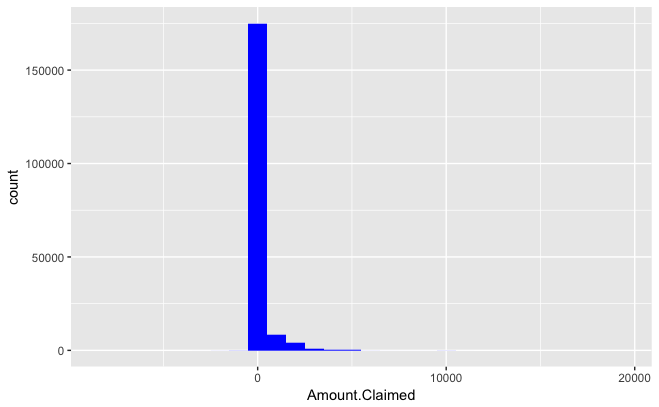

```r
#use the ggplot function with our dataset
ggplot(expenses16to18) +
  geom_histogram(aes(x=Amount.Claimed), #specify a histogram, and the column Amount.Claimed
                 binwidth=1000, #specify how wide each 'bin' (column) is
                 fill="blue") #specify a fill colour
```

The code to generate a density plot is similar:

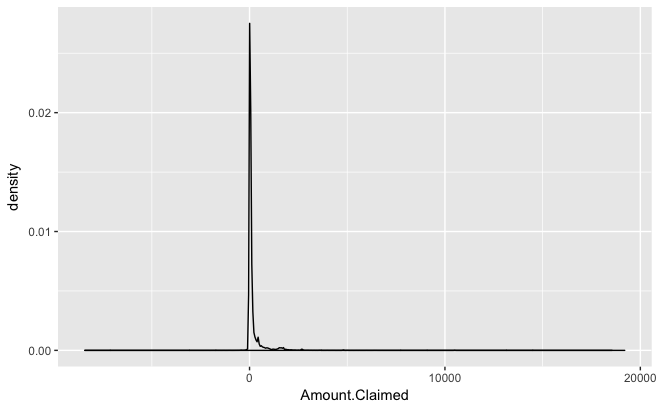

```r
#library(scales) #this allows us to add dollars to the numbers
#use the ggplot function with our dataset
ggplot(expenses16to18) +
  geom_density(aes(x=Amount.Claimed)) #specify a histogram, and the column Amount.Claimed
```

```r
                 #+ scale_x_continuous(labels=dollar) #specify the x axis labels as dollar amounts if needed
```

And for a column chart:

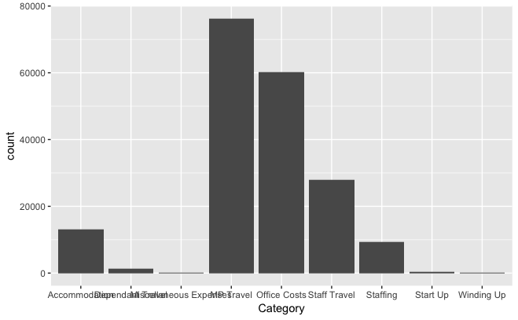

```r
#use the ggplot function with our dataset
ggplot(expenses16to18) +
  geom_bar(aes(x=Category)) #this needs to be a category, and entries will be counted
```

We can flip the axes by adding `+ coord_flip()` if we have a lot of categories and want a bar chart from the side - although with 650 categories it will still be difficult to read:

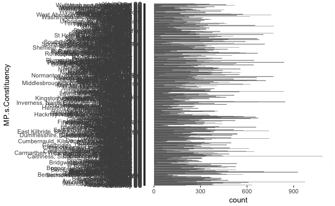

```r
#use the ggplot function with our dataset
ggplot(expenses16to18) +
  geom_bar(aes(x=MP.s.Constituency)) + coord_flip()
```

So we can add `theme` with arguments to specify the style:

```r
#use the ggplot function with our dataset
ggplot(expenses16to18) +
  geom_bar(aes(x=MP.s.Constituency)) + coord_flip() + theme(axis.text.y = element_text(size=rel(0.8)))
```

[output not shown]